# Simple, efficient, sound-and-complete combinator parsing for all context-free grammars, using an oracle.

Dr Tom Ridge

2013-11-08

# Prelude: quick intro to parsing and combinator parsing

# Quick question

- How many people have used combinator parsers?

# Basics of context-free grammars

Simple arithmetic expressions:

```
E -> E "+" E
E -> ?num?
```

or

```
E -> E "+" E | ?num?
```

Terminology: terminal, nonterminal, symbol, rule, grammar

N.B. RHS of rules cannot be the empty list

# Basics of parse trees

Each terminal is associated with a set of strings

Parse trees are trees which are well-formed according to the grammar, and where the strings associated with terminal nodes are those associated to the terminal at that node

[figure not shown]

# Parsing

Given a grammar, and an input string, parsing is the process of *determining* (somehow, and in some form) what parse trees correspond to the input.

There may be exponentially many parse trees:

```
E -> E E | "1"
```

There may be infinitely many parse trees:

```
E -> E | ""
```

# Combinator parsing

Represent rules for a nonterminal:

```
E -> "(" E "+" E ")"
  | "1"
```

By a recursive function:

```
(* following code ignores results and returns a dummy value *)
let rec parse_E i = (
  ((a "(") **> parse_E **> (a "+") **> parse_E **> (a ")"))
  ||| (a "1"))
  i
```

Given an input string `s`, a parser returns a list of things of the form `(v,s')`, where v is the result of parsing a prefix of `s`, and `s'` is the remainder of the input that wasn't parsed.

This is *prefix* parsing.

# Combinator parsing, terminal parsers

e.g. following used for `(a "1")` or more generally `(a s)`

```
let a s = (fun i ->
  if starts_with i s then
    let (u,v) = split i (String.length s) in
    [(u,v)]
  else
    [])

let _ = (a "1") "123"
(* [("1", "23")] *)

let _ = (a "1") "abc"
(* [] *)
```

# Combinator parsing, combinators

The combinators `|||` and `**>` are defined in the obvious way:

```
let (|||) p1 p2 = fun s -> List.append (p1 s) (p2 s)

let ( **> ) p1 p2 = (fun s0 ->
  (* apply p2 to results (e1,s1) from p1 *)
  let f (e1,s1) =
    p2 s1
    |> List.map (fun (e2,s2) -> ((e1,e2),s2))
  in
  s0
  |> p1
  |> List.map f
  |> List.concat)
```

Here, `x |> f` is just `f x`

Note these combinators are written infix e.g. `p1 **> p2`

```
let _ = ((a "1") **> (a "2")) "123"
(* [(("1", "2"), "3")] *)
```

# Combinator parsing, combinators

There is another function which we need, the "action" function:

```
let (>>) p f = (fun s ->
  s
  |> p
  |> List.map (fun (e,s) -> (f e, s)))
```

Note this is written infix e.g. `p >> f`

```
let _ = ((a "1") >> (fun _ -> 1))
(* "123" = [(1, "23")] *)
```

# With the following result

```
(* E -> "(" E "+" E ")" *)
let rec parse_E i =
  let f1 =
    ((a "(") **> parse_E **> (a "+") **> parse_E **> (a ")")
      >> (fun (_,(e1,(_,(e2,_)))) -> e1+e2))
    ||| ((a "1") >> (fun _ -> 1))
  in
  f1 i

let _ = parse_E "(1+(1+1))"
(* # - : (int * string) list = [(3, "")] *)
```

# The glory of combinator parsing

- Arguably the best programmer interface to parsing: full power of host functional language available (parameterization, modules, types, interactive use and debugging etc)

# Some problems with combinator parsing

- Cannot handle all grammars; e.g. no left recursion: the following leads to non-termination (or, more realistically, stack overflow)

```
E -> E "+" E | ...
```

```
E -> F G | F H
```

and also because prefix parsing can lead to lots of work which is eventually thrown away

```
E -> F "X"
F -> A B
```

In this example, assuming there is no `"X"` in the input, there may be substantial work involved in combining the results of parsing an `A` followed by parsing a `B`, before the parser attempts (and fails) to parse an `"X"`.

# Summary of problems

Combinator parsing has a great programmer interface, but lousy performance, and can't handle all context-free grammars.

# The goal

Consider a combinator parsing library with the following features:

- Handles all context-free grammars
- Sound
- Complete
- Conceptually simple (also, helps if implementation is simple)
- Efficient
- Real-world performance that matches or improves on the current-best parsers for any given subclass of context-free grammar

For context-free grammar parsing, this set of features, I would argue, is the best you could hope for.

# Sneak peak

# Motivating combinator parsing

In several recent publications academics have been trying to construct modular parsers, which can be easily combined in different ways.

Example: given a parser for lambda calculus, and a parser for arithmetic expressions, how to construct a parser for the combined language? e.g. parser accepts:

```
((\ y. y + 1) 2) + 3
```

In the following few slides: a modular presentation of parsers for 3 different languages, and their combination.

# Modular parsing: arithmetic

```
let rec parse_A h = (fun i -> mkntparser "arithexp" (

  (* plus expressions *)
  (((parse_A h) ***> w ***> (a "+") ***> w ***> (parse_A h))
   >>>> (fun (e1,(_,(_,(_,e2)))) -> `Plus(e1,e2)))

  |||| ...

  (* helper parser *)
  |||| h)
  i)
```

Note boilerplate.

The parser `w` parses whitespace.

The parser `h` is a "helper parser".

Note that this example includes left recursion: you can't do this with traditional combinator parsing.

# Modular parsing: arithmetic

And we can add in subtraction, numbers and brackets in the obvious way.

```
let rec parse_A h = (fun i -> mkntparser "arithexp" (
  ...
  (* subtraction *)
  |||| (((parse_A h) ***> w ***> (a "-") ***> w ***> (parse_A h))
        >>>> (fun (e1,(_,(_,(_,e2)))) -> `Minus(e1,e2)))

  (* numbers *)
  |||| (parse_num
        >>>> (fun s -> `Num(int_of_string (content s))))

  (* brackets *)
  |||| (((a "(") ***> w ***> (parse_A h) ***> w ***> (a ")"))
        >>>> (fun (_,(_,(e,(_,_)))) -> e))

  |||| ...)
  i)
```

# Parsing arithmetic expressions

```
  let txt = "1+2-3"

  let _ = (p3_run_parser (parse_A never) txt)
  (* [`Minus (`Plus (`Num 1, `Num 2), `Num 3);
  `Plus (`Num 1, `Minus (`Num 2, `Num 3))] *)
```

`never`, the helper parser in this example, is a parser that never parses.

Note multiple results - the grammar is ambiguous as well as left-recursive.

Interesting because it goes beyond traditional combinator parsing, but there is more!

# Parsing "boolean" expressions

```
let rec parse_B h = (fun i -> mkntparser "boolexp" (

  (* true and false *)
  ((a "true") >>>> (fun _ -> `Bool true))
  |||| ((a "false") >>>> (fun _ -> `Bool false))

  (* if-then-else expressions *)
  |||| (((a "if") ***> w ***> (parse_B h) ***> w ***>
            (a "then") ***> w ***> (parse_B h) ***> w ***>
            (a "else") ***> w ***> (parse_B h))
        >>>> (fun (_,(_,(b,(_,(_,(_,(e1,...))))))) -> `Ite(b,e1,e2)))

  (* numeric comparison < *)
  |||| (((parse_B h) ***> w ***> (a "<") ***> w ***> (parse_B h))
        >>>> (fun (e1,(_,(_,(_,e2)))) -> `Lt(e1,e2)))

  |||| h)
  i)
```

Again, note left recursion.

This is just an example; you might choose e.g. to include `<` in the arithmetic parser

# Parsing lambda expressions

```
let rec parse_L h = (fun i -> mkntparser "lambdaexp" (

  (* lambda: \ x body *)
  (((a "\\") ***> w ***> parse_var ***> w ***> (parse_L h))
   >>>> (fun (_,(_,(x,(_,body)))) -> `Lam(x,body)))

  (* application: u v *)
  |||| (((parse_L h) ***> w ***> (parse_L h))
        >>>> (fun (e1,(_,e2)) -> `App(e1,e2)))

  (* variables: x *)
  |||| (parse_var >>>> (fun s -> `Var s))  (* var *)

  (* brackets: (e) *)
  |||| (((a "(") ***> w ***> (parse_L h) ***> w ***> (a ")"))
        >>>> (fun (_,(_,(e,(_,_)))) -> e))

  |||| h)
  i)
```

- this is a very succinct and direct parser for lambda expressions
- there are no tricks: the grammar exactly matches the datatype

# Magic

We want a parser that can handle the language which includes all features of the previous 3 languages.

# Magic

We want a parser that can handle the language which includes all features of the previous 3 languages.

```
  let parse_U = (
    let rec l i = parse_L h i
    and a i = parse_A h i
    and b i = parse_B h i
    and h i = (??? what goes here???) i
    in
    l)
```

What is the missing definition of `h`?

*Hint: really only one possible answer for `h`*

# Magic

We want a parser that can handle the language which includes all features of the previous 3 languages.

```
  let parse_U = (
    let rec l i = parse_L h i
    and a i = parse_A h i
    and b i = parse_B h i
    and h i = (l |||| a |||| b) i
    in
    l)
```

Note the power of combinator parsing.

Note the power of "completeness" - all results are returned; so in particular all parsers return; so we don't need to worry about nontermination.

# Memoization

The version of `parse_U` on the previous slide is fine, but it can be made faster using memoization.

Memoization: `memo f i` is like `f i`, but saves the result and reuses it to avoid recomputation.

In the following, the memoization function `memo_p3` takes an explicit table argument, in which to store the results of computations.

```
  let parse_memo_U () = (
    let tbl = MyHashtbl.create 100 in
    let rec l i = memo_p3 tbl (parse_L h) i
    and a i = memo_p3 tbl (parse_A h) i
    and b i = memo_p3 tbl (parse_B h) i
    and h i = memo_p3 tbl (l |||| a |||| b) i
    in
    l)
```

Note the power of combinator parsing.

# Example

```
let txt = "\\ x if (1+((\\ y y) 2)) < 4 then true else false"

let _ = (p3_run_parser parse_U txt)

(*
[`Lam
   ("x",
    `Ite
      (`Lt (`Plus (`Num 1, `App (`Lam ("y", `Var "y"), `Num 2)), `Num 4),
       `Bool true, `Bool false))]
*)
```

Note nested recursion between grammars (lambda includes arith includes lambda etc)

# Modular evaluation

```
let rec eval_A h x = (match x with

| `Plus(e1,e2) -> (match (eval_A h e1,eval_A h e2) with
    | (`Num x, `Num y) -> `Num(x+y)
    | (x,y) -> `Err("eval_A 1",`Plus(x,y)))

  | `Minus(e1,e2) -> (match (eval_A h e1,eval_A h e2) with
    | (`Num x, `Num y) -> `Num(x-y)
    | (x,y) -> `Err("eval_A 2",`Minus(x,y)))

  | `Num x -> (`Num x)

  | _ -> h x)
```

Note we plan to evaluate e.g. "x+1", but this evaluator doesn't (and shouldn't) know anything about x, envs etc

# Modular evaluation, lambda expressions

```
let rec eval_L h env x = (match x with

  | `App(e1,e2) -> (
    let v1 = eval_L h env e1 in
    match v1 with
    | `Clos(env1,`Lam((x:string),e1)) -> (
      let env' = fupdate env1 (x,`Clos(env,e2)) in
      eval_L h env' e1)
    | _ -> `Err("eval_L 2",`App(v1,e2)))

  | `Lam(x,e) -> (`Clos(env,`Lam(x,e)))

  | `Var(x) -> (eval_L h env (env x))

  | `Clos(env,e) -> (eval_L h env e)

  | _ -> h env x)
```

Note need for an `env`.

Note how env is passed to the helper function: the evaluator for arithmetic expressions e.g. `x + 2` needs to know the value of `x` (but `eval_A` doesn't know anything about an `env`!)

The point is: the *helper* for `eval_A` needs to know the `env`, not `eval_A` itself

# Combining the evaluators

```
  let eval =
    let rec l env x = eval_L a env x
    and a env x = eval_A (b env) x
    and b env x = eval_B (eval_err env) x
    and eval_err env x = (match x with
      | `Err x -> `Err x
      | _ -> (l env x))
    in
    l
```

# Putting it all together

```
  let parse_and_eval txt = (
    p3_run_parser
      ((parse_memo_U ()) >>>> eval empty_env)
      txt)

  (* y is a lambda calculus fixpoint combinator *)
  let y = "(\\ f ((\\ x (f (x x))) (\\ x (f (x x)))))"
  (* sigma n = n + n-1 + ... + 1 *)
  let sigma = "(\\ g (\\ x (if (x < 2) then 1 else (x+(g (x-1))))))"
  let txt = "("^y^" "^sigma^") 5"
  let [r] = parse_and_eval txt
  (* `Num 15 *)
```

# Motivating soundness and completeness

It's about understanding what the behaviour is...

```
let rec parse_MANY p = (fun i -> (mkntparser ... (
  (((a "")) >>>> (fun _ -> []))
  |||| ((p ***> (parse_MANY p)) >>>> (fun (x,xs) -> x::xs))))
  i)
```

```
let parse_LIST bra elt sep ket = (
  let sep_elt = (sep ***> elt) >>>> (fun (_,e) -> e) in
  ((bra ***> ket) >>>> (fun _ -> []))
  |||| ((bra ***> elt ***> parse_MANY(sep_elt) ***> ket)
    >>>> (fun (_,(e,(es,_))) -> e::es)))
```

```
let _ = p3_run_parser (parse_LIST (a "[") (a "x") (a ";") (a "]")) "[x;x;x]"

let _ = p3_run_parser (parse_LIST (a "") (a "x") (a "") (a "")) "xxx"
(* i.e. ... = parse_MANY (a "x") *)
```

Support for equational reasoning about parsers: `(a "") ***> p =~ p` etc

# What do I mean by efficient?

- Distinguish between parsing time, and time to execute the actions
- Efficient, practical parsers execute in time $O(n^3)$ (where n is the length of the input)
- Real-world performance also needs to be acceptable

> For every polynomial-time algorithm you have, there is an exponential algorithm that I would rather run. (Perlis)

# The talk proper

# Outline

- Semantics of parsing
- Key ideas, and a bit of implementation code
- Some measurements
- The state of play
- Conclusion

# Semantics of parsing

- What does sound and complete mean for a parser?

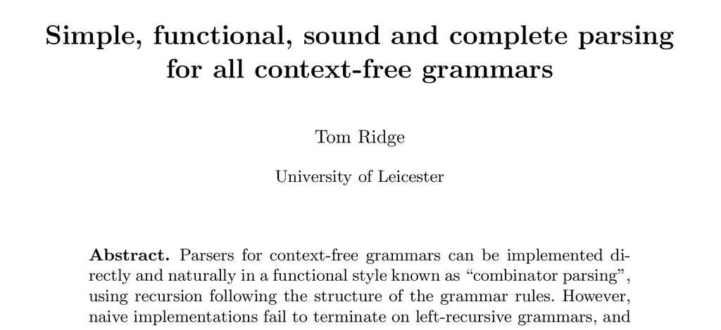

# Soundness

- Soundness means: every parse tree returned is well-formed according to the grammar.

# Completeness

- Completeness (almost) means: every parse tree that is well-formed according to the grammar is returned.
- Problem: there may be an infinite number of parse trees

e.g.

```
E -> E E E | "1" | ""

 E         E              E
 |       / | \          / | \
"1"     E  E  E       ""  E  ""
        |  |  |         / | \
       "" "1" ""       E  E  E
                       |  |  |
                      "" "1" ""
```

# A reasonable definition of completeness

What causes the number of parse trees to be infinite?

```
         E
       / | \
      .  .  .
     .   .   .
    .    .    .
   .     .     .
  .      .      .
 /       |       \
 ""..."" E  ""...""
```

In general you need: a nonterminal (E say) and a sequence of productions

```
E ->+ "" ... "" E "" ... ""
```

# Bad and good parse trees

- Bad parse trees are such as those in the previous slide
- Good parse trees are those that do not contain a bad subtree
- There are only a finite (but typically very large) number of good parse trees
- They embody all parsing information
- It is possible to motivate good parse trees in several other ways, but that is beyond the scope of this talk

# Completeness

- Completeness means: every good parse tree is returned.

# Fixing combinator parsing to handle all context-free grammars

- If we restrict to good parse trees, it is possible to construct combinator parsers that are sound and complete (CPP'11).
- At the implementation level we use a parsing context. Parsing contexts eliminate bad trees.
- A parsing context is a set of pairs (X,s), where X is a nonterminal and s is a string
- The meaning of the context is something like "A parse of nonterminal X on string s is already in process"
- If you attempt to parse the same nonterminal on the same string, you abandon the parse.
- Somewhat more complicated than this because combinator parsing is prefix parsing
- For details, see CPP'11 paper

# Semantics of parsing, summary

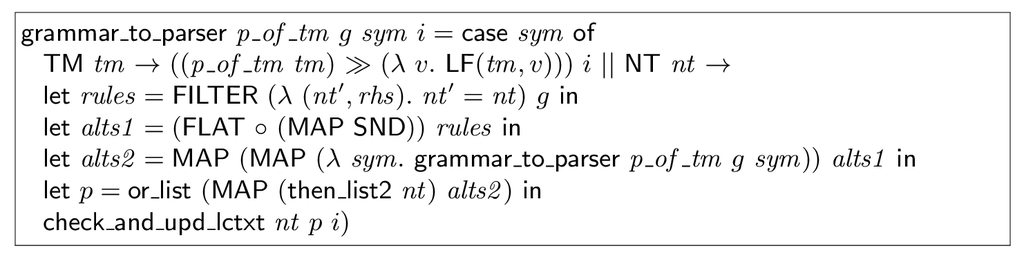

- Sound, complete, mechanized proof in HOL4
- Executable, usable as a reference parser
- Mechanization interesting for other reasons
  - wellformedness conditions on terminal parsers (lexing is a form of disambiguation)
  - what is the maximum depth of a good parse tree? $|NT|*(n+1)$ ☜ [link](http://richard.myweb.cs.uwindsor.ca/PUBLICATIONS/PADL_08.pdf)
- My current view on "semantics of parsing" ☜
- Efficiency: parsing worst case $O(n^5)$, but it often achieves this worst case ☹ ☜

# A new approach

# Time to think again

- We can handle context-free grammars ☺
- Takes a long time ☹
- Thinks... thinks...
- Conclusion: difficult to preserve simplicity of combinator parsing and also achieve good performance (but sophisticated implementation techniques such as trampolining may get there - see GLL)

# Time to think again

- Revisit goals, weaken...
- Abandon combinator parsing as a parsing technique, but retain as the programmer interface
  - the user's conceptual model *must* remain simple
- Use any other technique to do the actual parsing
  - our implementation is based on Earley parsing; the implementation can be horribly complicated providing no details intrude on the user's mental model
- The problem now is to reconcile an interface based on combinator parsing with an existing technique such as Earley parsing
- Another problem is to implement Earley parsing correctly and efficiently (I won't discuss this further in this talk)

# Two different worlds

- Combinator parsing is well integrated with the host language

```
let rec parse_E = (fun i -> (mkntparser "E" (
  ((parse_E ***> parse_E ***> parse_E) >>>> (fun (x,(y,z)) -> x+y+z))
  |||| ((a "1") >>>> (fun _ -> 1))
  |||| ((a "") >>>> (fun _ -> 0))))
  i)
```

- Earley parsing uses concrete datastructures

```
let g = [
  ("E",[NT "E";NT "E";NT "E"]);
  ("E",[TM "1"]);
  ("E",[TM "eps"])]
```

- Picture (SD) of proposed approach ☜
- If the programmer writes code such as `parse_E` there is no obvious way to get a grammar such as g

# Idea, forced

- Somehow interpret the combinators in different ways
- In one way, we can write the function `grammar_of_parser` such that

```
grammar_of_parser parse_E = [
  ("E",[NT "E";NT "E";NT "E"]);
  ("E",[TM "1"]);
  ("E",[TM "eps"])]
```

- In another way, `parse_E` appears to behave as a standard combinator parser

# Solution

- The input type is no longer a string, but a (3-way) sum type

```
type ('a,'b,'c) sum3 = Inl of 'a | Inm of 'b | Inr of 'c
```

- Think of 3 components: left, middle and right
- A parser is a function with the following type

```
type input = (inl,inm,inr) sum3
type 'a output = (outl,outm,'a outr) sum3
```

- Given an argument of type `inl`, it gives a result of type `outl`, etc

# Left component

```
type inl = unit
type outl = symbol

type input = (inl,inm,inr) sum3
type 'a output = (outl,outm,'a outr) sum3
type 'a parser3 = (input -> 'a output)
```

Given an argument `Inl()`, a parser returns a value of form `Inl(sym)`

```
parse_E (Inl()) = Inl(NT("E"))
```

Define the following function

```
let sym_of_parser p = (dest_inl (p (Inl ())))
```

# Middle component

```
type mid = {
  rules7: parse_rule list;
  tmparsers7: (term,raw_parser) fmap
}
type inm = mid
type outm = mid

type input = (inl,inm,inr) sum3
type 'a output = (outl,outm,'a outr) sum3
type 'a parser3 = (input -> 'a output)
```

Given an argument of type `Inm mid`, a parser (such as `parse_E`) returns a value of form `Inm mid'`, where `mid'` is `mid` extended with all grammar rules "reachable" from the relevant symbol (such as `E`). Must be careful about termination.

Also collects all the terminal parsers. Example...

# Middle component

```
let grammar_of_parser p = (dest_inm (p (Inm empty_mid)))
```

Then

```
grammar_of_parser parse_E = {
  rules7=[("(E*E)", Seq (NT "E", NT "E"));
    ("(E*(E*E))", Seq (NT "E", NT "(E*E)"));
    ("((E*(E*E))+1)", Alt (NT "(E*(E*E))", TM "1"));
    ("(((E*(E*E))+1)+eps)",Alt(NT "((E*(E*E))+1)",TM "eps"));
    ("E", Atom (NT "(((E*(E*E))+1)+eps)"))];
  ...
}
```

# Earley parsing

We can extract the grammar from a parser.

We feed this to an Earley parser, and we get back information about the parse.

This information needs to be in a compact form (e.g. not parse trees!). I use an oracle.

# Oracle

A top-down parser:

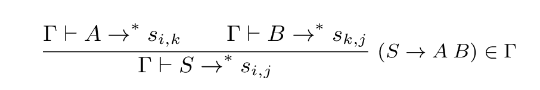

The oracle answers the following problem:

Given a rule $S \rightarrow A B$ in $\Gamma$ and a substring $s_{i,j}$, what are the indexes $k$ such that $\Gamma \vdash A \rightarrow^* s_{i,k}$ and $\Gamma \vdash B \rightarrow^* S_{k,j}$ ?

In code:

```
type ty_oracle = (symbol * symbol) -> substring -> int list
```

A substring is $s_{i,j}$, or `SS(s,i,j)` in code

# Right component

```
type inr = {
  ss4: substring;
  lc4: local_context;
  oracle4: ty_oracle
}
type 'a outr = 'a list

type input = (inl,inm,inr) sum3
type 'a output = (outl,outm,'a outr) sum3
type 'a parser3 = (input -> 'a output)
```

The right component corresponds to the usual combinator parser. The `ss4` field is the input string, `lc4` is the parsing context (to eliminate bad trees) and `oracle4` is the parsing information returned by the Earley parser.

# Definition of combinators

What happens when executing `(p1 ***> p2) (Inr i0)`?

```
let seqr p1 p2 = (fun i0 ->
  (* get symbol for each parser *)
  let sym1 = sym_of_parser p1 in
  let sym2 = sym_of_parser p2 in
  let SS(s,i,j) = i0.ss4 in
  (* call oracle on substring SS(s,i,j), get back list of k s *)
  let ks = i0.oracle4 (sym1,sym2) i0.ss4 in
  (* for each k we do the following *)
  let f1 k = (
    (* call p1 on SS(s,i,k) ... *)
    let rs1 = dest_inr (p1 (Inr { i0 with ss4=(SS(s,i,k)) })) in
    (* ... and p2 on SS(s,k,j) .. *)
    let rs2 = dest_inr (p2 (Inr { i0 with ss4=(SS(s,k,j)) })) in
    (* and combine the results *)
    list_product rs1 rs2)
  in
  List.concat (List.map f1 ks))
```

# What's missing from these slides

- Complete definitions of combinators
- Code for the Earley parser (surprisingly difficult to get right)

# Experiments (on version 2013-05-15)

- Various grammars, various inputs

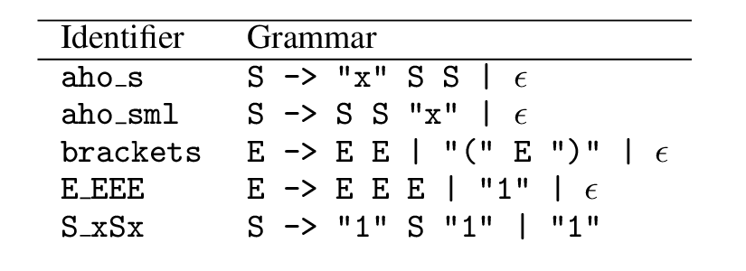

- We want to compare the performance of my approach (P3) with existing approaches; none of the existing approaches have a combinator interface
- First problem: most parsers cannot actually parse these grammars; if they can, they typically bug out with very small inputs
- Haskell Happy parser is the only one I found that allowed me to run a respectable number of tests

# Performance comparison with Happy

- On grammars `aho_s` and `E_EEE`, P3 clearly outperforms Happy, e.g. for `aho_s`

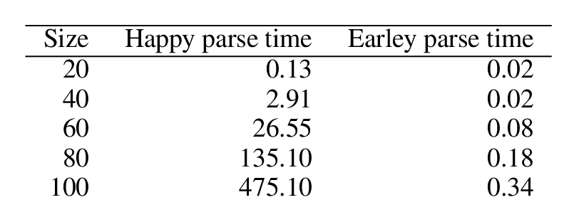

- There is (probably) a performance bug in Happy
- On `brackets`, Happy bugged out. This is (probably) a functional correctness bug in Happy.

# Performance comparison with Happy

- On `S_xSx` and `aho_sml`, P3 is worse than Happy by a small (2-4) factor. Following is `S_xSx`:

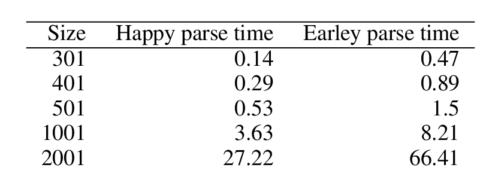

- However, Earley appears to be asymptotically better than Happy on these grammars, and so with big enough inputs, Earley would win; unfortunately Happy ran out of memory before this could be evidenced (probably another memory usage/gc bug)

# Performance

- There is also additional overhead after parsing: constructing the oracle and executing the actions
- With the released version, constructing the oracle can take about as long as parsing
- Executing the actions appears to behave as it should (i.e. best possible performance that could be expected)
- The released version does not attain $O(n^3)$ bound (but Happy is even worse)
- A new implementation of Earley combines parsing with oracle construction, cuts execution time by a significant factor, and appears to fit the expected bound (actually $O(n^3.ln(n))$).

# State of play

- The initial release is usable. No bugs found so far. Lacks features that would make it really usable (e.g. debugging features)
- The new version can work with arbitrary input types, not just strings. So you can use a lexer.
- The new version fixes a minor annoyance with memoization.
- The new version has significant performance improvements.
- The new version has some support for debugging.
- I use this technology all the time e.g. to port Netsem spec to Lem

# Conclusion

- Combinator parsing library; fancy examples
- Good performance, competitive with best parsers currently around; oracle architecture means we can swap in faster parsers when they become available; we can even analyse the grammar and choose the fastest parser for the given grammar class
- New version (to be released before Christmas hopefully) has even better performance
  - I also plan to start using other backends for restricted grammar classes
- Needs a bit more engineering e.g. to support debugging
- Main challenges: good trees; oracle architecture; 3 interpretations of combinators; Earley implementation; correctness and efficiency; tying everything together
- I should verify the implementation of Earley
- I should test performance on large grammars from restricted classes, against existing parsers for these subclasses.